# Max Tjen: 459 Homework 1

Max Tjen

2023-02-22

## 0.1 Setup

```r
library(rstatix)
library(reshape2)
library(GGally)
library(tidyverse)

theme_set(theme_bw())
```

## 0.2 Data Import

```r
aids_data <- read_csv("/Users/mtjen/Desktop/459/homework/hw1/aids.csv")

head(aids_data)
```

```
# A tibble: 6 × 12
  patient  Time death   CD4 obstime drug  gender prevOI AZT      start
    <dbl> <dbl> <dbl> <dbl>   <dbl> <chr> <chr>  <chr>  <chr>    <dbl>
1       1  17.0     0 10.7        0 ddC   male   AIDS   intoler…     0
2       1  17.0     0  8.43       6 ddC   male   AIDS   intoler…     6
3       1  17.0     0  9.43      12 ddC   male   AIDS   intoler…    12
4       2  19       0  6.32       0 ddI   male   noAIDS intoler…     0
5       2  19       0  8.12       6 ddI   male   noAIDS intoler…     6
6       2  19       0  4.58      12 ddI   male   noAIDS intoler…    12
# … with 2 more variables: stop <dbl>, event <dbl>
```

# 1 Question 1

```r
q1_data <- aids_data

# pivot data from long to wide format
q1_data <- q1_data |>
  pivot_wider(names_from = "obstime",
              values_from = "CD4")

# rename observation time variables
names(q1_data)[names(q1_data) == "0"] <- "T0"
names(q1_data)[names(q1_data) == "2"] <- "T2"
names(q1_data)[names(q1_data) == "6"] <- "T6"
names(q1_data)[names(q1_data) == "12"] <- "T12"
names(q1_data)[names(q1_data) == "18"] <- "T18"

# reposition "T2" between "T0" and "T6"
q1_data <- q1_data |>
  relocate("T2", .after = "T0")

head(q1_data)
```

```
# A tibble: 6 × 15
  patient  Time death drug  gender prevOI AZT        start  stop event
    <dbl> <dbl> <dbl> <chr> <chr>  <chr>  <chr>      <dbl> <dbl> <dbl>
1       1  17.0     0 ddC   male   AIDS   intoleran…     0   6       0
2       1  17.0     0 ddC   male   AIDS   intoleran…     6  12       0
3       1  17.0     0 ddC   male   AIDS   intoleran…    12  17.0     0
4       2  19       0 ddI   male   noAIDS intoleran…     0   6       0
5       2  19       0 ddI   male   noAIDS intoleran…     6  12       0
6       2  19       0 ddI   male   noAIDS intoleran…    12  18       0
# … with 5 more variables: T0 <dbl>, T2 <dbl>, T6 <dbl>, T12 <dbl>,
#   T18 <dbl>
```

Here, we convert the data from long format to wide format so that the times of observations are more clear. After that, we repositioned one of the variables (T2) so that all of the observation times are chronologically ordered. Now, each of the time variables (T0 … T18) represents the time period of the CD4 observation. To keep all the variables, we didn’t collapse rows of same patients to keep the start and stop variables as their values for each observation are different.

# 2 Question 2

```r
# make new dataset
q2_data <- q1_data |>
  select(patient, T0, T2, T6, T12, T18)

# group data by patient
q2_data <- q2_data |>
  group_by(patient) |>
  summarise_if(is.numeric, sum, na.rm = TRUE)

# turn 0 values to NA since NA's were converted to 0 during grouping
q2_data[q2_data == 0] <- NA

head(q2_data)
```

```
# A tibble: 6 × 6
  patient    T0    T2    T6   T12   T18
    <dbl> <dbl> <dbl> <dbl> <dbl> <dbl>
1       1 10.7  NA     8.43  9.43    NA
2       2  6.32 NA     8.12  4.58     5
3       3  3.46  3.61  6.16 NA       NA
4       4  3.87  4.58  2.65  1.73    NA
5       5  7.28  8.60  8.60  6.71    NA
6       6  4.58 NA    NA    NA       NA
```

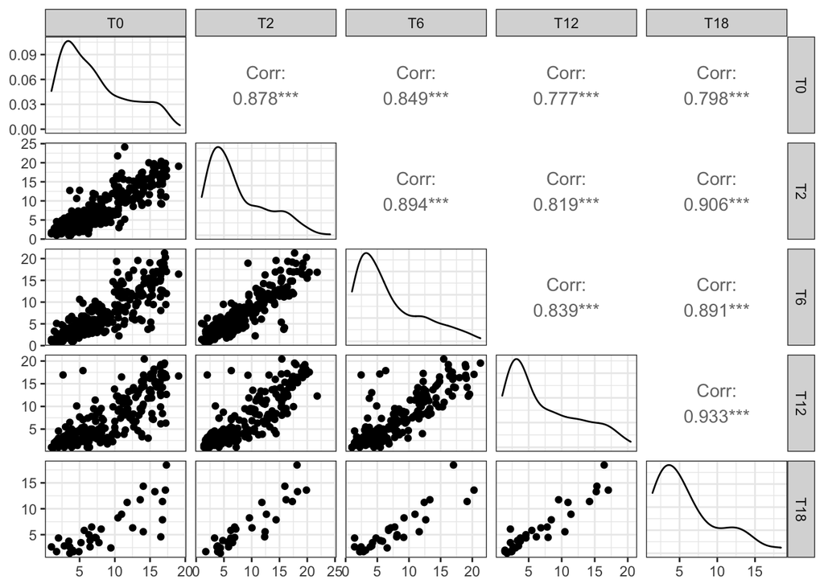

```r
# remove patient
q2_data <- q2_data |>
  select(-patient)

# get correlations
ggpairs(q2_data)
```

From the correlation matrix, it appears that the repeated measurements of CD4 values are correlated by patient. For all of the time groups, the lowest correlation value is 0.777 between time 0 and time 12, which still indicates strong correlation. Furthermore, the correlations are very evident by looking at the scatter plots, where each plot appears to have a strong linear trend.

# 3 Question 3

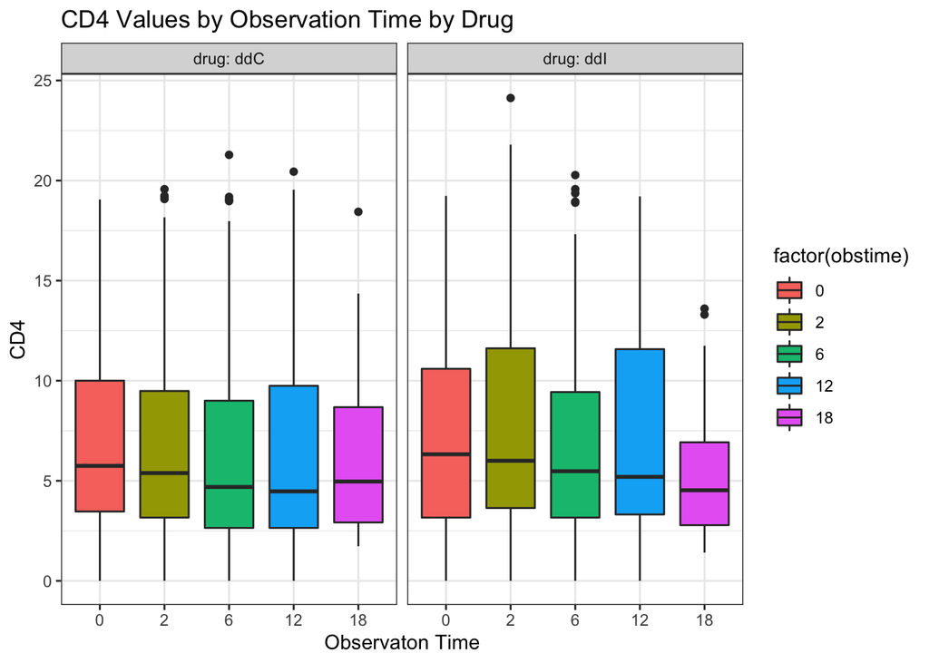

```r
# create plot to visualize longitudinal data
ggplot(aids_data, aes(x = factor(obstime), y = CD4, fill = factor(obstime))) +
  geom_boxplot() +
  facet_wrap(~drug, labeller = "label_both") +
  labs(title = "CD4 Values by Observation Time by Drug",
       x = "Observaton Time",
       y = "CD4")
```

```r
# get median values of ddC by group
aids_data |>
  filter(drug == "ddC") |>
  group_by(obstime) |>
  summarise(median(CD4))
```

```
# A tibble: 5 × 2
  obstime `median(CD4)`
    <dbl>         <dbl>
1       0          5.74
2       2          5.39
3       6          4.69
4      12          4.47
5      18          4.96
```

```r
# get median values of ddI by group
aids_data |>
  filter(drug == "ddI") |>
  group_by(obstime) |>
  summarise(median(CD4))
```

```
# A tibble: 5 × 2
  obstime `median(CD4)`
    <dbl>         <dbl>
1       0          6.32
2       2          6.00
3       6          5.48
4      12          5.20
5      18          4.53
```

To explore the longitudinal trend of CD4 over various observation time points, we used a boxplot to see CD4 by observation time for each drug. We chose this because the plot clearly differentiates each observation time point and we can easily compare them by looking at quartile values, inter quartile range, and outliers. From this plot, we can see that CD4 value distributions for each drug are relatively similar for all the observation points. For the ddC drug, we can see that from time 0 to time 12, the median CD4 consistently decreases but from time 12 to 18, the median increases. For the ddI drug, the median CD4 value decreases over every time period. This can be confirmed by looking at the precise median CD4 values for each drug, where we can also observe that drug ddI has a greater impact on decreasing CD4 than ddC based on the overall change in median CD4 values for each.